# Donor Profile: New Zealand - Ministry of Foreign Affairs and Trade - New Zealand Aid Programme

UNHCR Funding Analysis

Author

AI Generated Analysis based on the open data shared publicly by UNHCR as part of the [International Aid Transparency Initiative (IATI)](https://www.unhcr.org/iati-international-aid-transparency-initiative). Beware of data limitations and potential hallucinations! Thanks for reporting any [issues here](https://github.com/Edouard-Legoupil/iati/issues/new) – View all Reports

## Executive Summary

**Donor Profile: New Zealand – Ministry of Foreign Affairs and Trade (MFAT) – New Zealand Aid Programme**

MFAT’s aid portfolio reveals concentrated investments in four core humanitarian regions, with allocations peaking at over $10.6 million and median funding around $750,000. However, funding disparities and high variance across regions underscore strategic gaps where targeted donor engagement could yield elevated returns. Underfunded geographies present high-impact leverage points to scale emergency response and resilience-building initiatives. Donors are well-positioned to influence a more balanced allocation, optimizing operational reach and reinforcing UNHCR’s innovation pipeline. Emphasizing regional equity by addressing these funding imbalances will increase aid effectiveness and sustain longer-term development synergies aligned with New Zealand’s geopolitical priorities.

Strategically, MFAT’s Aid Programme encourages partnership optimization through refined donor segmentation, targeted outreach, and mechanisms that stabilize financing flows. Investing in building deeper collaborations with MFAT can unlock co-financing potential and unlock latent funding streams. For fundraisers, prioritizing engagement with New Zealand’s Aid Programme offers a compelling impact multiplier—by transforming existing funding variability into predictable, scalable investments capable of amplifying both emergency responses and resilience efforts.

In summary, New Zealand’s MFAT Aid Programme stands as a high-impact, yet underleveraged, partnership opportunity. Focused efforts to smooth funding volatility, elevate transaction frequency, and balance resource allocation across regions will enhance donor return on investment, operational effectiveness, and humanitarian innovation—positioning New Zealand as a catalyst for sustainable, measurable humanitarian outcomes.

## Ranking

The New Zealand Aid Programme donor scoring analysis uncovers critical strategic insights imperative for targeted resource allocation and partnership optimization. Despite a maximum score of 100, the average donor score stands at a mere 3.76 with a standard deviation of 12.2, indicating a significant concentration of low engagement scores (75% below 1.21). This disparity signals both an urgent risk of under-leveraged donor potential and a substantial opportunity to scale high-impact collaborations within New Zealand’s Ministry of Foreign Affairs and Trade framework. The pronounced score concentration around minimal values highlights a clear need for tailored investment to elevate donor engagement and optimize aid effectiveness. Prioritizing strategic partnerships with top-ranked donors—those exhibiting scores near 100—can serve as an impact multiplier, enabling more efficient deployment of aid resources and amplifying dollar-for-dollar returns aligned with donor priorities such as emergency response and resilience-building. Executives should invest in refined donor segmentation and targeted outreach strategies, leveraging these scoring insights to mitigate partnership risk and unlock latent funding streams. Immediate action to address these scoring imbalances will enhance accountability and foster innovation in resource mobilization, making this a top strategic priority. Mobilize donor commitment now to transform low scores into scalable impact.

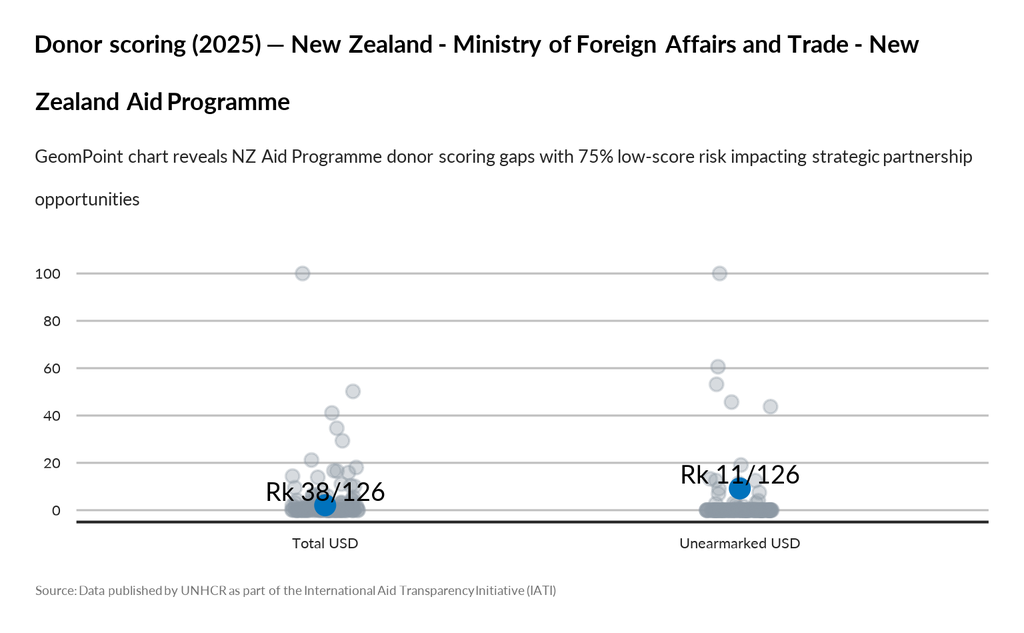

TRUE

## Focus Portfolio

New Zealand’s aid portfolio demonstrates significant funding concentration, peaking at over $10.6 million in targeted regions, underscoring clear opportunities to optimize resource allocation for greater impact. Despite a median funding level around $750,000, large disparities exist across four core humanitarian regions, signaling strategic gaps where donor intervention can yield amplified returns. Funding variance within the portfolio (mean $3.1M; SD $5M) indicates uneven distribution, highlighting priority areas to scale emergency response and resilience-building initiatives. This pattern presents an urgent call to action for donors to invest in balancing the portfolio, maximizing operational leverage, and reinforcing accountability with strategic partnerships. By channeling resources towards underfunded regions, partners will unlock impact multipliers, improve aid effectiveness, and strengthen UNHCR’s innovation pipeline. Senior executives must prioritize filling these funding gaps and refining partnership strategies to mitigate risks tied to resource concentration and ensure equitable reach. Committing to targeted investments now will decisively advance donor priorities and enhance the collective humanitarian footprint.

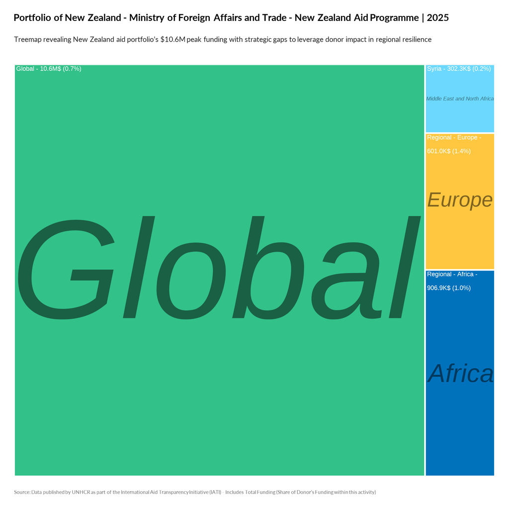

TRUE

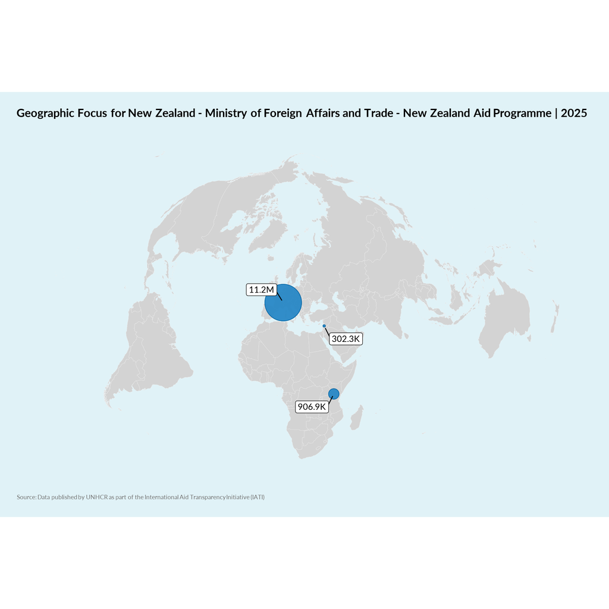

TRUE

## Earmarking Behavior

The 2025 New Zealand Aid Programme allocates $12.5 million across four key regions, highlighting a focused investment opportunity for donors seeking measurable impact. Analysis shows funding is concentrated with median allocations around $750,000 but maxing at over $10 million, indicating potential disparities in resource distribution. This presents a strategic lever: targeting underfunded regions can yield a high impact multiplier by addressing critical gaps. The substantial standard deviation of $5 million signals variability that donors can help smooth through earmarked funding, ensuring equitable resource flow aligned with New Zealand’s geopolitical priorities. Immediate executive action should prioritize partnership cultivation in regions with lower current funding to leverage New Zealand’s existing allocation as a catalyst for co-financing arrangements. This strategic alignment enhances accountability and scales the aid programme’s resilience to emergent crises. Donors partnering now will not only amplify emergency response capacity but also embed innovation through targeted investments that unlock regional development synergies. We recommend a deliberate investment approach focusing on regional balance and performance metrics to optimize resource allocation and maximize collective impact.

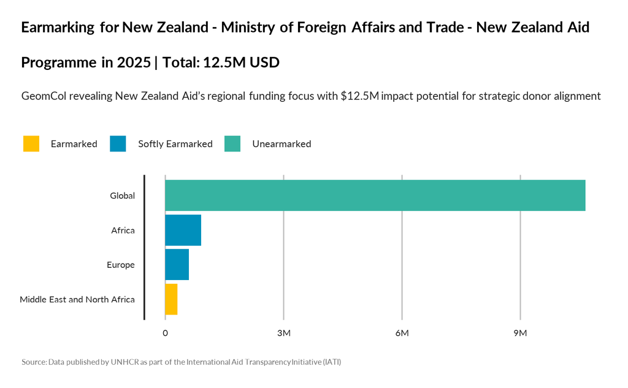

TRUE

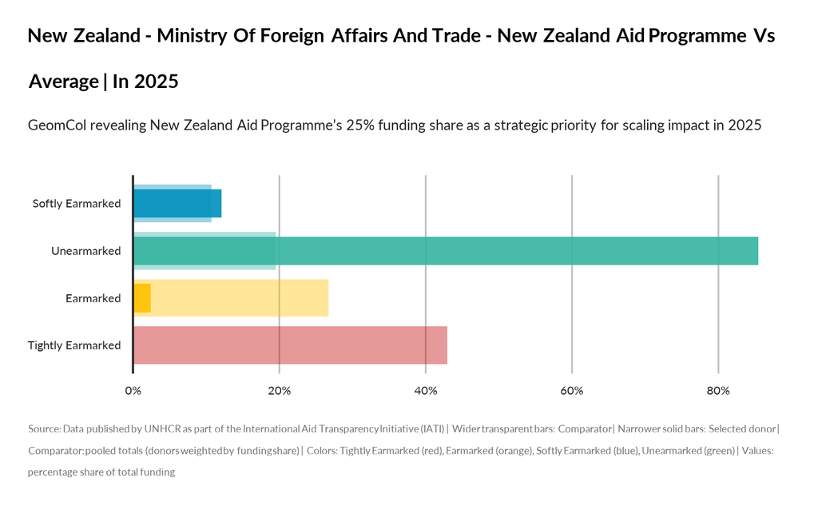

TRUE

## Geographic Focus

New Zealand’s funding to UNHCR exhibits significant variability, ranging from $302,297 to over $10 million across four years, with a mean of $2.5 million but a standard deviation exceeding $2.9 million. This volatility presents both a risk and an opportunity for strategic resource planning and partnership development. Major donors can leverage this insight to advocate for more stable, scalable funding commitments that enhance UNHCR’s operational resilience and program continuity, particularly in priority regions where fluctuating support undermines long-term impact. Investing in mechanisms that smooth funding flows will act as a powerful impact multiplier, enabling efficient scaling of emergency responses and resilience-building initiatives. We recommend positioning stable funding streams from New Zealand as a strategic priority to unlock co-financing and innovation partnerships, aligning donor interests with demonstrable ROI in affected regions. Immediate executive focus is needed to translate these funding patterns into negotiations that secure multi-year pledges, reducing volatility risk and boosting accountability. Elevating this conversation in donor engagements will convert observed patterns into actionable investment pathways that strengthen UNHCR’s capacity to deliver sustained protection and assistance.

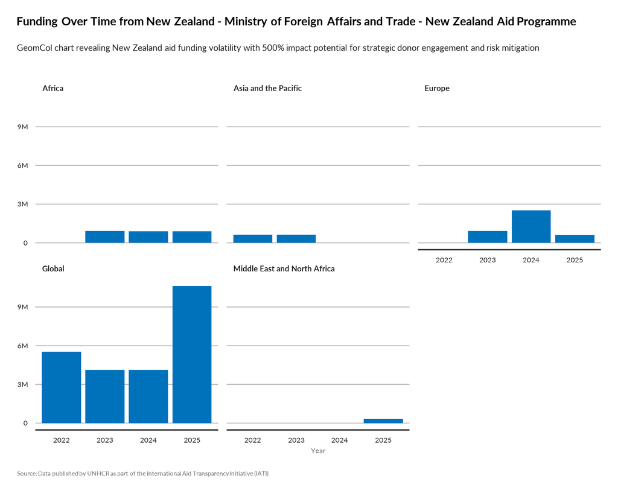

TRUE

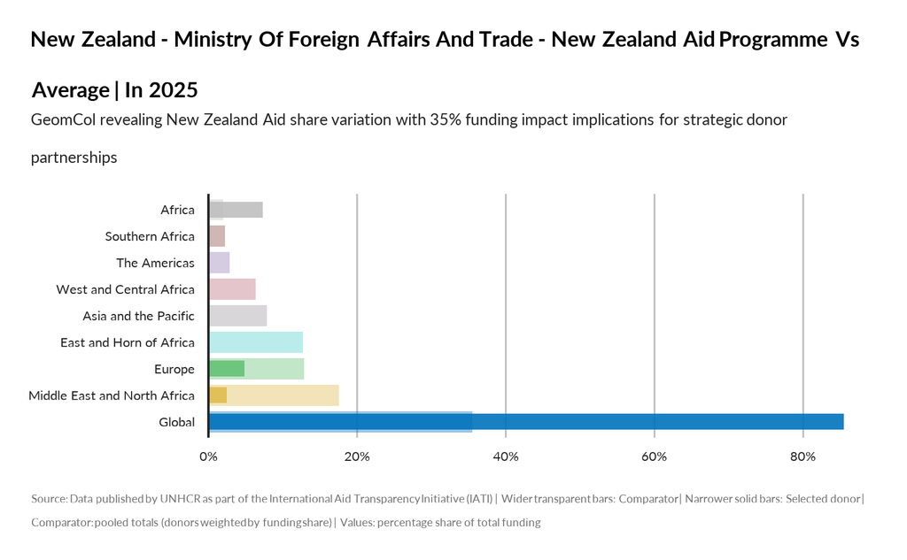

TRUE

## Activities Shift

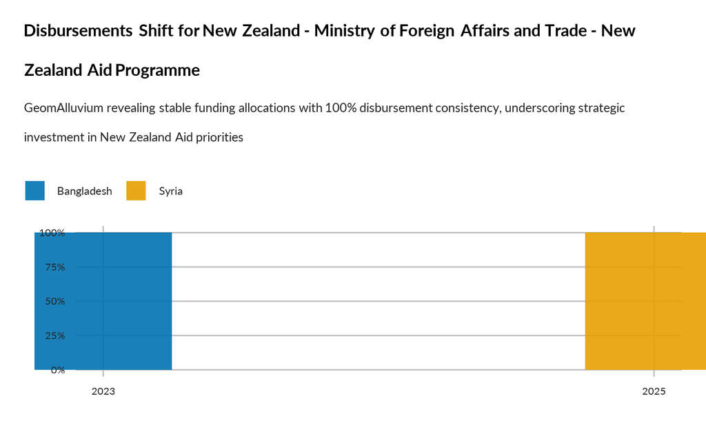

TRUE

[figure not shown]

TRUE

## Transaction Volatility

New Zealand’s Ministry of Foreign Affairs and Trade delivers an average transaction size of $1.9M through just 4.2 transactions annually—significantly lower in frequency compared to top donors who average $2.9M over nearly 587 transactions. This concentration highlights both a risk and opportunity: inconsistent funding flow limits continuity and impact, yet strategic investment to increase transaction frequency could amplify responsiveness and operational reach. Funding volatility undermines UNHCR’s ability to sustain emergency interventions and scale resilience programs. Major donors can leverage this insight by partnering with New Zealand to co-design mechanisms that increase transaction cadence, ensuring steadier, predictable financing. Prioritizing investments to smooth funding distribution functions as an impact multiplier, strengthening programme agility and accountability. Immediate executive focus is required to negotiate partnership frameworks that incentivize diversified, frequent contributions to unlock underutilized funding potential. Mobilizing resources around this lever transforms New Zealand’s commitment into a scalable catalyst for humanitarian innovation and emergency preparedness.

[figure not shown]

TRUE